# Assignment #2

## Abstraction

This dataset is the gene expression profiling of MDA231, BT549 and SUM159PT celles after selumetinib treatment or DUSP4 siRNA knockdown. MDA231, BT549 and SUM159PT basal-like breast cancer cell lines were transfected with non-targeting siRNA (siCONTROL), siRNA targeting DUSP4 (siDUSP4), or siCONTROL + 4 or 24 hr of 1uM selumetinib. The data were log2 RMA normalized.  
This dataset has 36 samples which can be separated to 3 groups by different cell lines (MDA231, SUM159PT, BT549). Each cell line has 12 samples which can be separated to 2 groups by different drug treatments (DMSO, Selumetinib). Each drug treatment has 3 controls and 3 cases.

## Visualization

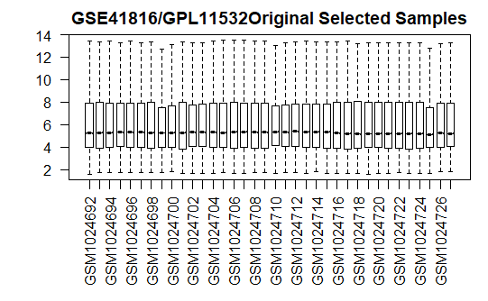

This is the Boxplot of the original data.

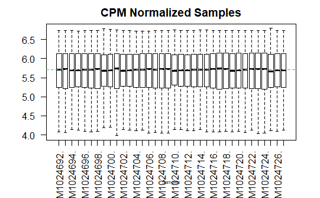

The boxplot shows the data after normalization, log2 ratio and cpm were used.

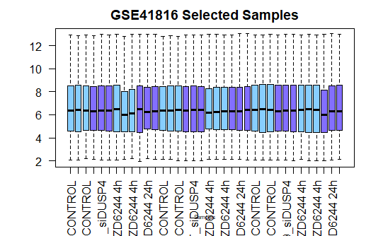

Boxplot from original data, blue color represents the CONTROL samples, and the purple color represents the CASE.

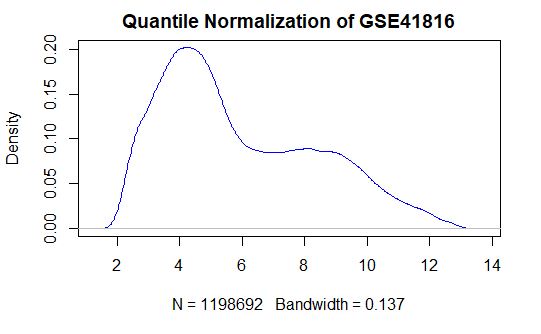

Plot of GSE41816 database by using quantile normalization.

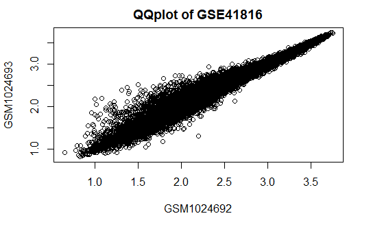

QQ-Plot of GSE41816 database.

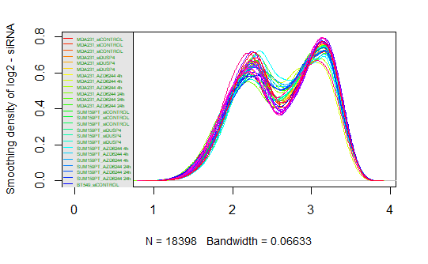

This is the density plot by using log2 ratio for the original data.

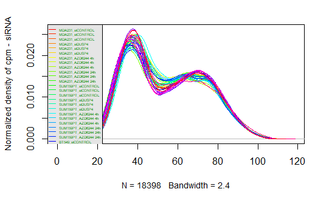

This the density plot after using cpm function.

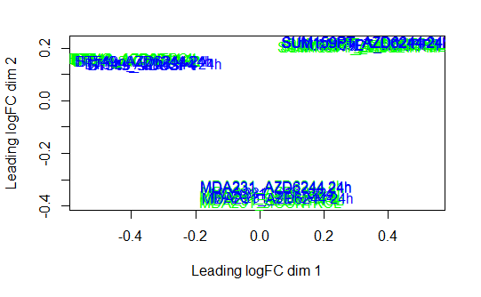

MDS plot shows the relation between CONTROL and CASE. The relation between CONTROL and CASE are pretty close. The most differences are between differet cell types.

```
[1] 947
[1] 292
[1] 613
[1] 334
```

The glmQLFTest from edgeR package is based on the cell line MDA231. There are 947 genes pass the threshold p-value which less than 0.05. There are 292 genes pass correction, 613 genes are up regulated and 334 genes are down regulated.

|  | logFC | logCPM | F | PValue | FDR |
| --- | --- | --- | --- | --- | --- |
| ENSG00000166825 | -1.325501 | 6.598318 | 4881.474 | 1.953507e-10 | 3.594062e-06 |
| ENSG00000148677 | 1.290621 | 6.270545 | 3539.259 | 1.307444e-09 | 7.207435e-06 |
| ENSG00000164176 | 1.359398 | 6.437174 | 2132.666 | 1.394339e-09 | 7.207435e-06 |
| ENSG00000171345 | 1.312254 | 6.168467 | 3735.305 | 1.567004e-09 | 7.207435e-06 |
| ENSG00000138685 | -1.354013 | 6.291498 | 2052.621 | 1.980686e-09 | 7.288132e-06 |
| ENSG00000178860 | -1.321900 | 6.311231 | 1592.114 | 2.913912e-09 | 7.611416e-06 |

[output not shown]

[output cut: 71 more lines]

```
ENSG00000178860     11.143030     11.195160
                X.GSM1024724. X.GSM1024725.
ENSG00000166825     12.384330     12.250760
ENSG00000148677      4.981931      4.183184
ENSG00000164176      3.578350      3.727744
ENSG00000171345      4.532353      4.249921
ENSG00000138685     10.521600     10.465490
ENSG00000178860     11.307790     11.036660
                X.GSM1024726. X.GSM1024727.
ENSG00000166825     12.491760     12.457070
ENSG00000148677      4.678524      5.022226
ENSG00000164176      4.292710      4.114725
ENSG00000171345      4.680730      4.616951
ENSG00000138685     10.690850     10.609710
ENSG00000178860     11.094830     11.062190
```

This is part of the table contents after linear fit and calculating the p-values. These two tables return the top hits which ranked by p-values and the corresponding original numeric data.

```
[1] "ENSG00000117602" "ENSG00000175793"
[3] "ENSG00000162599" "ENSG00000184588"
[5] "ENSG00000099260" "ENSG00000134247"
```

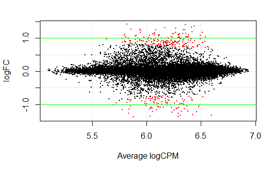

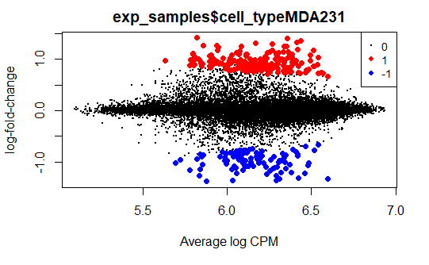

Extract differential expressed genes, there is a part of genes names showing above. These two plots are used to visualize the amount of differentially expressed genes.

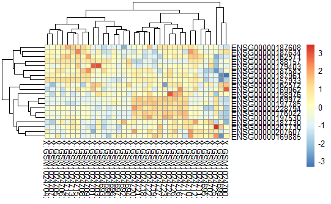

The heatmap only contains the first 20 rows data. (The data is too large, it’s hard to show all the results clearly.)

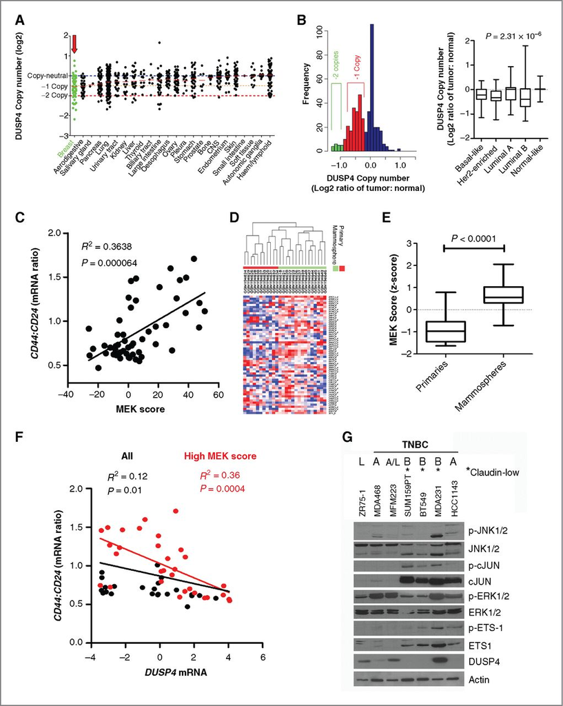

Image from Original Paper

## Reference

1. Balko, J. M., Schwarz, L. J., Bhola, N. E., Kurupi, R., Owens, P., Miller, T. W., . Arteaga, C. L. (2013, October 15). Activation of MAPK pathways due to DUSP4 loss promotes cancer stem cell-like phenotypes in basal-like breast cancer. Retrieved from https://www.ncbi.nlm.nih.gov/pubmed/23966295
2. https://www.ncbi.nlm.nih.gov/geo/query/acc.cgi?acc=GSE41816
3. hugene11sttranscriptcluster.db. (n.d.). Retrieved from http://bioconductor.org/packages/release/data/annotation/html/hugene11sttranscriptcluster.db.html
4. Davis, S. and Meltzer, P. S. GEOquery: a bridge between the Gene Expression Omnibus (GEO) and BioConductor. Bioinformatics, 2007, 14, 1846-1847
5. Orchestrating high-throughput genomic analysis with Bioconductor. W. Huber, V.J. Carey, R. Gentleman, …, M. Morgan Nature Methods, 2015:12, 115.
6. Ritchie, M.E., Phipson, B., Wu, D., Hu, Y., Law, C.W., Shi, W., and Smyth, G.K. (2015). limma powers differential expression analyses for RNA-sequencing and microarray studies. Nucleic Acids Research 43(7), e47.
7. Robinson MD, McCarthy DJ and Smyth GK (2010). edgeR: a Bioconductor package for differential expression analysis of digital gene expression data. Bioinformatics 26, 139-140
8. McCarthy DJ, Chen Y and Smyth GK (2012). Differential expression analysis of multifactor RNA-Seq experiments with respect to biological variation. Nucleic Acids Research 40, 4288-4297